# Fire Service Survey: Initial Exploration and insights

David Marx  
2/3/2017

### Background

- Fire Service Survey
- 5458 Records (respondents)
- Year unknown, post 2011 (per Q5)

### The Survey

[figure not shown]

### Suggestions for improvement to survey

- Questions prompting numeric responses unnecessarily broken out into ordinal variables reduces data granularity
  - Number of buildings with 3+ stories (Q3)
  - Minimum staffing (Q7-Q10)
- Some questions poorly binned, resulting in skipped ranges and requiring “other” category
  - Firefighter fitness (Q22d/f)
- Inconsistent binning choice across similar questions
  - Hazmat training level prompts for precise percentages
  - Other types of training ask respondent to check a box representing a range

### But most importantly...

- Migrate to electronic survey platform
  - Minimize errors from multiple human data-entry steps
  - Automatic data integrity checks (e.g. percents add up to 100)
  - Ensure necessary questions are not left blank

### Suggestions for improvement to dataset

### Large numeric values used xx,xxx comma delimiting

- Forces coersion to text
- Necessitates otherwise unnecessary data cleaning step
- Fewer characters for data entry = less work for data entry personnel

### Preparing Data

### Cleaning Nulls

- For the purpose of this analysis, it is assumed that null entries on questions asking for numeric values are equivalent to a reponse of “0”
- Cleaning in this fashion had the additional effect of creating a new “null” category on questions associated with categorical/ordinal variables, since categories are otherwise 1-indexed in the data
- Normally I would advise performing this kind of cleaning operation on a variable-by-variable basis. Broad strokes are dangerous, but time was limited in this analysis.

### Preparing Data

### Cleaning Numbers

- Stripped commas prior to numeric coersion, being careful to avoid stripping commas from text columns

### FINDINGS

- Staffing levels (paid) are stable
- Women have stronger representation in volunteer departments

### Staffing levels (paid) are stable

52% of departments have no full-time paid personnel. Of those that have paid personnel, 99% of departments are within 2% of paid staffing levels from 2011.

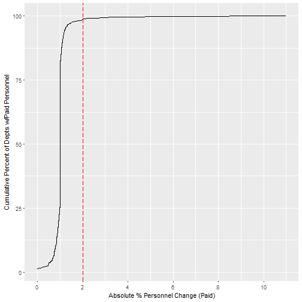

### Representation of Women

- Controlling for department size, women have higher representation in volunteer departments
- 21% of volunteer departments had at least 14% female staff, whereas only 1% of paid departments did.

### Decision Boundary

Approximately 14% representation

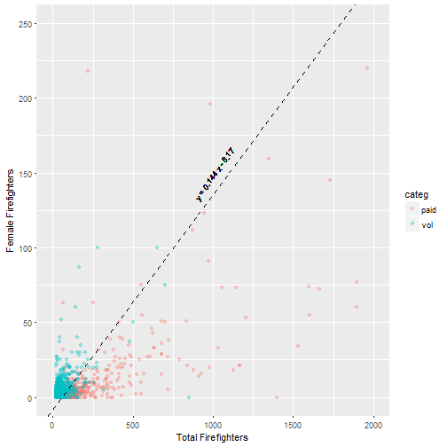

### Representation of Women: Boring technical details

- Logistic regression
- Relative effect on odds ratio of female_ff vs total_ff: 7x

```
    is_volunteer_dept ~ total_ff + female_ff

             Estimate Std. Error z value Pr(>|z|)
(Intercept)  1.641406   0.061250   26.80   <2e-16 ***
female_ff    0.200858   0.012611   15.93   <2e-16 ***
total_ff    -0.028968   0.001392  -20.81   <2e-16 ***
```

### Model Validation

- Bootstrapped accuracy (200 iterations): 77.0% (95% CI: 75.3% - 78.7%),
- p < 0.005 (permutation test)
- Area Under ROC Curve: 0.84

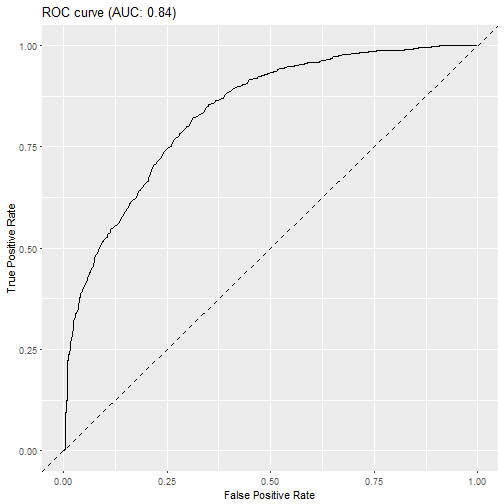

### Future work

- More closely investigate variables associated with FD needs
- Be more careful with null data
- Revisit gender analysis with zero-inflated modeling
- Play with free text fields